# Module 04: SEM, Regression, and Causal Inference

Computational Social Science — Graduate & Undergraduate

2026-04-04

# 1 Overview

This module covers two related topics. The first is **Structural Equation Modeling (SEM)** — the extension of CFA (Module 3) to models that also include directed causal paths between latent variables. The second is **causal inference** — the collection of strategies for drawing causal conclusions from observational data.

These topics share a common concern: under what conditions does a statistical association in data justify a causal interpretation? SEM makes causal assumptions explicit in the model structure. Causal inference methods provide design-based strategies for relaxing the assumptions that make causal claims credible.

**Learning goals:**

- Run and read OLS regression output fully — coefficients, SEs, R², F-test, diagnostics
- Specify and estimate a complete SEM with lavaan
- Read the full lavaan SEM output section by section
- Decompose effects into direct, indirect, and total (mediation)
- Draw and read a DAG; identify backdoor paths, confounders, and colliders
- Understand the 2×2 DiD design and the parallel trends assumption
- Apply propensity score matching and assess balance

# 2 Part A: OLS Regression — The Foundation

## 2.1 Why Start Here

SEM is, fundamentally, an extension of regression. Understanding regression deeply — not just how to run it but how to read every piece of output, check every assumption, and interpret every coefficient — is the prerequisite for understanding SEM. Students who skip this often misinterpret SEM results because they are applying a technique they have not mastered in its simpler form.

## 2.2 A Complete Regression Workflow

We use the GSS 2018 to study the predictors of reported happiness. The outcome is `happy` (1=very happy, 2=pretty happy, 3=not too happy — *lower is happier*). Predictors: education, age, sex, income, and political ideology.

```r
library(gssr)
data(gss_all)

gss18 <- gss_all |>
  filter(year == 2018) |>
  select(happy, educ, age, sex, income16, polviews, degree, trust) |>
  mutate(across(everything(), as.numeric)) |>
  filter(if_all(everything(), ~!is.na(.x) & .x < 98))

cat("GSS 2018 complete cases:", nrow(gss18), "\n")
```

```
## GSS 2018 complete cases: 1378
```

```r
cat("Variables:", paste(names(gss18), collapse=", "), "\n\n")
```

```
## Variables: happy, educ, age, sex, income16, polviews, degree, trust
```

```r
# Describe the outcome
cat("Distribution of happy (1=very happy, 2=pretty, 3=not too):\n")
```

```
## Distribution of happy (1=very happy, 2=pretty, 3=not too):
```

```r
table(gss18$happy) |> prop.table() |> round(3) |> print()
```

```
##
##     1     2     3
## 0.297 0.544 0.160
```

```r
# Step 1: Simple regression — one predictor
m_simple <- lm(happy ~ educ, data = gss18)
summary(m_simple)
```

```
##
## Call:
## lm(formula = happy ~ educ, data = gss18)
##
## Residuals:
##     Min      1Q  Median      3Q     Max
## -1.0788 -0.8111  0.1220  0.1722  1.2391
##
## Coefficients:
##              Estimate Std. Error t value Pr(>|t|)
## (Intercept)  2.095572   0.088061  23.797  < 2e-16 ***
## educ        -0.016735   0.006202  -2.698  0.00705 **
## ---
## Signif. codes:  0 '***' 0.001 '**' 0.01 '*' 0.05 '.' 0.1 ' ' 1
##
## Residual standard error: 0.6603 on 1376 degrees of freedom
## Multiple R-squared:  0.005264,   Adjusted R-squared:  0.004541
## F-statistic: 7.282 on 1 and 1376 DF,  p-value: 0.007052
```

**Reading every line of this output:**

Reading lm() Summary Output — Every Line Explained

| Output Line | What It Means |
| --- | --- |
| Call: | The formula you specified. Always verify this matches your intent. |
| Residuals: Min / 1Q / Median / 3Q / Max | Five-number summary of errors (observed minus predicted). Median near 0 = symmetric errors. Min and Max show outlier presence. |
| Coefficients: (Intercept) Estimate | Predicted happy when educ = 0 (no education). Not always meaningful — depends on whether X = 0 occurs in your data. |
| (Intercept) Std. Error | Uncertainty in the intercept estimate. Used to compute t and confidence interval. |
| (Intercept) t value | Intercept / Std.Error. Used to test whether intercept ≠ 0 (usually unimportant). |
| (Intercept) Pr(>\|t\|) | P-value for the intercept. Usually irrelevant — we rarely care whether the intercept is zero. |
| educ Estimate | The slope: for each 1-year increase in education, happy changes by this amount ON AVERAGE. Negative = more education → lower score → happier. |
| Signif. codes | *** = p < .001 \| ** = p < .01 \| * = p < .05 \| . = p < .10 \| (blank) = p > .10 |
| Residual standard error | Average size of prediction errors in the same units as Y. Lower = better predictions. |
| Multiple R-squared | Proportion of Y variance explained by X. Ranges 0–1. This is r² when there is one predictor. |
| Adjusted R-squared | R² penalised for the number of predictors. Use this when comparing models with different numbers of predictors. |
| F-statistic + p-value | Tests whether the whole model explains more than chance (H₀: all slopes = 0). p < .05 = at least one predictor matters. |

## 2.3 Multiple Regression — Adding Predictors

```r
m_full <- lm(happy ~ educ + age + I(sex == 2) + income16 + polviews,
             data = gss18)
summary(m_full)
```

```
##
## Call:
## lm(formula = happy ~ educ + age + I(sex == 2) + income16 + polviews,
##     data = gss18)
##
## Residuals:
##     Min      1Q  Median      3Q     Max
## -1.4042 -0.6547  0.1146  0.2908  1.4605
##
## Coefficients:
##                   Estimate Std. Error t value Pr(>|t|)
## (Intercept)      2.5195727  0.1128982  22.317  < 2e-16 ***
## educ             0.0053561  0.0066615   0.804  0.42151
## age             -0.0018261  0.0009968  -1.832  0.06717 .
## I(sex == 2)TRUE -0.0141088  0.0347373  -0.406  0.68469
## income16        -0.0286574  0.0032706  -8.762  < 2e-16 ***
## polviews        -0.0303610  0.0115998  -2.617  0.00896 **
## ---
## Signif. codes:  0 '***' 0.001 '**' 0.01 '*' 0.05 '.' 0.1 ' ' 1
##
## Residual standard error: 0.6396 on 1372 degrees of freedom
## Multiple R-squared:  0.06938,    Adjusted R-squared:  0.06598
## F-statistic: 20.46 on 5 and 1372 DF,  p-value: < 2.2e-16
```

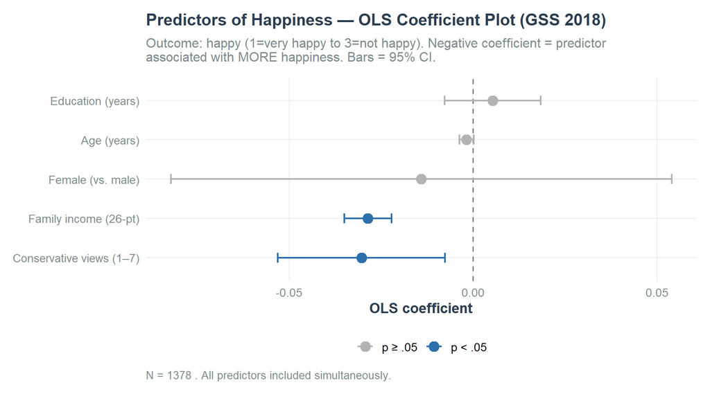

```r
broom::tidy(m_full, conf.int=TRUE) |>
  filter(term != "(Intercept)") |>
  mutate(
    term = dplyr::recode(term,
      "educ"            = "Education (years)",
      "age"             = "Age (years)",
      "I(sex == 2)TRUE" = "Female (vs. male)",
      "income16"        = "Family income (26-pt)",
      "polviews"        = "Conservative views (1–7)"
    ),
    sig = p.value < .05
  ) |>
  ggplot(aes(x=estimate, y=reorder(term,estimate), colour=sig)) +
  geom_vline(xintercept=0, linetype="dashed", colour="grey50") +
  geom_point(size=4) +
  geom_errorbarh(aes(xmin=conf.low, xmax=conf.high), height=0.25, linewidth=0.8) +
  scale_colour_manual(values=c("TRUE"="#2C6FAC","FALSE"="grey70"),
                      labels=c("TRUE"="p < .05","FALSE"="p ≥ .05"),
                      name=NULL) +
  labs(
    title    = "Predictors of Happiness — OLS Coefficient Plot (GSS 2018)",
    subtitle = paste("Outcome: happy (1=very happy to 3=not happy). Negative coefficient = predictor",
                     "\nassociated with MORE happiness. Bars = 95% CI."),
    x="OLS coefficient", y=NULL,
    caption  = paste("N =", nrow(gss18), ". All predictors included simultaneously.")
  ) +
  theme(legend.position="bottom")
```

**Interpreting multiple regression coefficients:**

Each coefficient is the estimated association of that predictor with Y *holding all other predictors constant*. This “holding constant” is what makes multiple regression more informative than a series of bivariate correlations — it lets you ask “what is the education-happiness relationship among people of the same age, sex, and income?”

- `income16` coefficient: for each step up the 26-point income scale (about $5,000 increase), happiness changes by this amount on average, among people with the same education, age, sex, and political views.
- `polviews` coefficient: among people identical in all other measured characteristics, conservatives report slightly different happiness than liberals.

## 2.4 Regression Assumptions and Diagnostics

Every regression rests on assumptions. Violating them does not always make the analysis worthless, but it can bias estimates or inflate Type I error rates. Check them routinely.

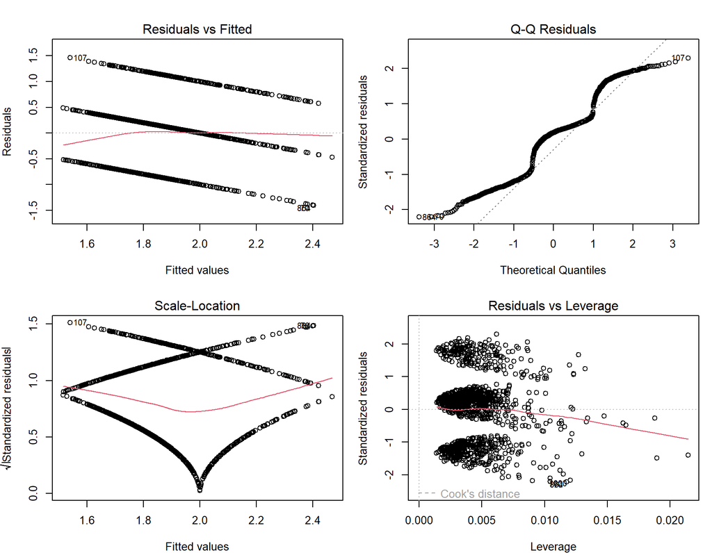

```r
# The four standard diagnostic plots
old_par <- par(mfrow=c(2,2), mar=c(4,4,3,1))
plot(m_full)
```

```r
par(old_par)
```

Reading the Four Standard OLS Diagnostic Plots

| Plot | What to Look For | Action If Problematic |
| --- | --- | --- |
| Residuals vs Fitted | Points should scatter randomly around the horizontal line at 0 (no pattern). A U-shape or funnel indicates nonlinearity or heteroscedasticity. | Try transforming Y or X (log, sqrt). Or use robust standard errors (sandwich estimator). |
| Normal Q-Q | Points should fall along the diagonal line. Heavy deviations in the tails indicate non-normal residuals (important for small N; less critical for large N by CLT). | For large N: usually ignorable (CLT). For small N: consider robust methods or nonparametric tests. |
| Scale-Location | Spread of standardised residuals should be roughly constant across fitted values. Increasing spread = heteroscedasticity → standard errors are wrong → p-values are unreliable. | Use heteroscedasticity-consistent (HC) standard errors: lm_robust() from estimatr package. |
| Residuals vs Leverage | Points far right (high leverage) or above the dashed Cook’s distance lines are influential — they disproportionately pull the regression line. Investigate these cases. | Examine flagged cases. Are they data errors? Do they represent a distinct subgroup? Report sensitivity analysis without them. |